# 6 Boston Housing

Adam Fishbaugh

2022 - 08 - 18

## Background

You have been hired by the tax authority of the City of Boston to asses Tax Assessments. Your task is to create a model to predict the av_total (assessed value) of properties in the greater Boston area.

### READ THIS

keep your code organized, I’m not giving you required steps you need to figure out how to build a regression model, explore the data, partition the data etc. this is just an outline of how i’d approach this problem, you can choose to do something different. this needs to be your own work!!

## Libraries

load your libraries

```r
options(scipen = 999)
library(tidyverse)
library(broom)
library(modelr)
library(skimr)
library(janitor)
library(reshape2)
library(magick)
library(ggpubr)
library(corrplot)
library(psych)
```

## Import

boston.csv zips.csv

I’d use clean names but it’s up to you…

```r
#Upload Boston Houses Data
boston_data <- read_csv("boston.csv") %>% clean_names() %>%
  #change zipcode to match 5 digit code on zips data
  mutate(zipcode = paste("0", zipcode, sep = "")) %>%
  mutate(pid = as.factor(pid))
boston_data
```

```
## # A tibble: 9,483 × 28
##    pid        zipcode own_occ av_total land_sf yr_built yr_remod living_area
##    <fct>      <chr>   <chr>      <dbl>   <dbl>    <dbl>    <dbl>       <dbl>
##  1 1812296230 02136   Y         321200   10288     1992        0        1681
##  2 2006736000 02132   Y         894400   10148     1900     2016        3024
##  3 2009442000 02132   Y         387700    8512     1920        0        1160
##  4 1704953000 02124   Y         450500    3187     1900     2001        1868
##  5 1812269079 02136   Y         325100   10088     1971     1975        1534
##  6 2011986000 02132   Y         408800    3500     1960     1987        1632
##  7 1902260006 02130   Y         794300    6007     1962     2001        2146
##  8 1807363000 02136   Y         342100    5500     1949     2002        1357
##  9 1601441000 02124   Y         444700    3026     1900        0        2346
## 10 2004674000 02131   Y         518500    4950     1900     2012        2032
## # … with 9,473 more rows, and 20 more variables: num_floors <dbl>,
## #   structure_class <chr>, r_bldg_styl <chr>, r_roof_typ <chr>,
## #   r_ext_fin <chr>, r_total_rms <dbl>, r_bdrms <dbl>, r_full_bth <dbl>,
## #   r_half_bth <dbl>, r_bth_style <chr>, r_kitch <dbl>, r_kitch_style <chr>,
## #   r_heat_typ <chr>, r_ac <chr>, r_fplace <dbl>, r_ext_cnd <chr>,
## #   r_ovrall_cnd <chr>, r_int_cnd <chr>, r_int_fin <chr>, r_view <chr>
```

```r
#Import Boston Zip-Code Data
zips_data <- read_csv("zips.csv") %>% clean_names() %>%
  mutate(city_state = as.factor(city_state))
zips_data
```

```
## # A tibble: 6 × 5
##   zip   population pop_density median_income city_state
##   <chr>      <dbl>       <dbl>         <dbl> <fct>
## 1 02132      36314       13251         75446 Cambridge, MA
## 2 02124      47783       15913         48841 Dorchester Center, MA
## 3 02131      29826       11505         66735 Roslindale, MA
## 4 02136      28488        6207         58890 Hyde Park, MA
## 5 02130      35401       10618         75730 Jamaica Plain, MA
## 6 02138      36314       13251         75446 Cambridge, MA
```

## Explore AV_TOTAL

what’s the average av_total?

1. make a histogram of av_total
2. make a box plot of av_total

```r
#Assessed_Value_Property
av_mean <- mean(boston_data$av_total)
av_mean
```

```
## [1] 447391
```

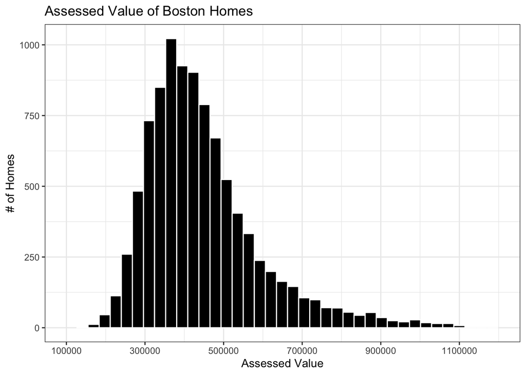

```r
#Histogram of AV_Total
 boston_data %>% ggplot(aes(av_total)) +
  geom_histogram( bins = 40, colour= "white", fill = "black")+
  theme_bw() +
  ggtitle("Assessed Value of Boston Homes") +
  scale_x_continuous(name = "Assessed Value",
                     limits = c(100000, 1200000),
                     breaks = seq(100000, 1200000, 200000))+
  scale_y_continuous(name = "# of Homes")
```

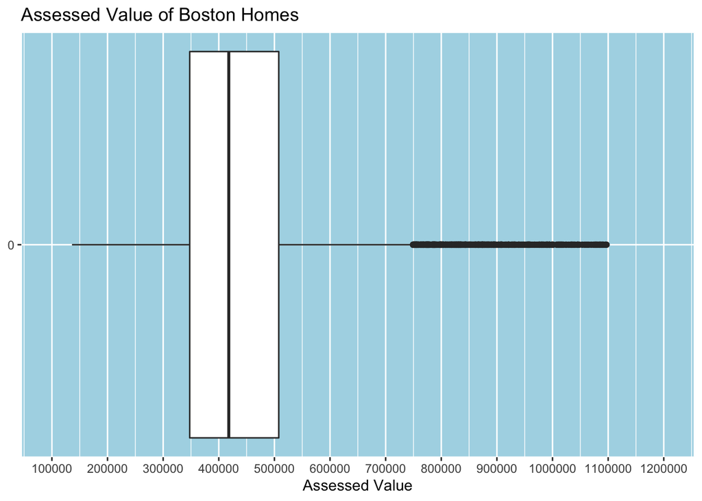

```r
 #BOXPLOT of AV_Total
boston_data %>% ggplot(aes(av_total)) +
  geom_boxplot() +
  theme(panel.background = element_rect(fill = "lightblue",
                                colour = "white",
                                size = 0.5, linetype = "solid")) +
  ggtitle("Assessed Value of Boston Homes") +
  scale_x_continuous(name = "Assessed Value",
                     limits = c(100000, 1200000),
                     breaks = seq(100000, 1200000, 100000)) +
  scale_y_continuous(breaks = FALSE)
```

## Transform

there are a number of helpful transfomations you can make but here is what i’d minamaly do:

1. join boston to zips on zipcode = zip,
- note zip is character you’ll need to convert it to an integer.
2. create a home age variable using some form of logic
- IF yr_remod > yr_built THEN age = 2020 - yr_remod
- ELSE age = 2020 - yr_built

```r
combined_set <- boston_data %>%
  inner_join(zips_data, by = c("zipcode" = "zip")) %>%
  #home_age variable since remodel
  mutate(home_age = if_else(yr_remod > yr_built,2020 - yr_remod, 2020 - yr_built))
combined_set
```

```
## # A tibble: 9,483 × 33
##    pid        zipcode own_occ av_total land_sf yr_built yr_remod living_area
##    <fct>      <chr>   <chr>      <dbl>   <dbl>    <dbl>    <dbl>       <dbl>
##  1 1812296230 02136   Y         321200   10288     1992        0        1681
##  2 2006736000 02132   Y         894400   10148     1900     2016        3024
##  3 2009442000 02132   Y         387700    8512     1920        0        1160
##  4 1704953000 02124   Y         450500    3187     1900     2001        1868
##  5 1812269079 02136   Y         325100   10088     1971     1975        1534
##  6 2011986000 02132   Y         408800    3500     1960     1987        1632
##  7 1902260006 02130   Y         794300    6007     1962     2001        2146
##  8 1807363000 02136   Y         342100    5500     1949     2002        1357
##  9 1601441000 02124   Y         444700    3026     1900        0        2346
## 10 2004674000 02131   Y         518500    4950     1900     2012        2032
## # … with 9,473 more rows, and 25 more variables: num_floors <dbl>,
## #   structure_class <chr>, r_bldg_styl <chr>, r_roof_typ <chr>,
## #   r_ext_fin <chr>, r_total_rms <dbl>, r_bdrms <dbl>, r_full_bth <dbl>,
## #   r_half_bth <dbl>, r_bth_style <chr>, r_kitch <dbl>, r_kitch_style <chr>,
## #   r_heat_typ <chr>, r_ac <chr>, r_fplace <dbl>, r_ext_cnd <chr>,
## #   r_ovrall_cnd <chr>, r_int_cnd <chr>, r_int_fin <chr>, r_view <chr>,
## #   population <dbl>, pop_density <dbl>, median_income <dbl>, …
```

## Explore Categorical Variables

I’d do some kind of null analysis and frequency analysis, what variables can i exclude?

```r
#Null analysis -- ~ 1 = random chance --
lmnull <- lm(combined_set$av_total ~ 1)
summary(lmnull)
```

```
##
## Call:
## lm(formula = combined_set$av_total ~ 1)
##
## Residuals:
##     Min      1Q  Median      3Q     Max
## -311291  -99641  -29391   60459  649709
##
## Coefficients:
##             Estimate Std. Error t value            Pr(>|t|)
## (Intercept)   447391       1503   297.7 <0.0000000000000002 ***
## ---
## Signif. codes:  0 '***' 0.001 '**' 0.01 '*' 0.05 '.' 0.1 ' ' 1
##
## Residual standard error: 146400 on 9482 degrees of freedom
```

```r
#Frequency Analysis
categorical_freq_count <- combined_set %>%
  summarise(across(is.character, n_distinct, na.rm = TRUE)) %>%
  mutate(stat = "distinct")
categorical_freq_count
```

```
## # A tibble: 1 × 16
##   zipcode own_occ structure_class r_bldg_styl r_roof_typ r_ext_fin r_bth_style
##     <int>   <int>           <int>       <int>      <int>     <int>       <int>
## 1       5       2               1          16          7        11           4
## # … with 9 more variables: r_kitch_style <int>, r_heat_typ <int>, r_ac <int>,
## #   r_ext_cnd <int>, r_ovrall_cnd <int>, r_int_cnd <int>, r_int_fin <int>,
## #   r_view <int>, stat <chr>
```

```r
combined_set <- combined_set %>%
  filter(!is.na(yr_remod),
  !is.na(home_age),
  !is.na (land_sf),
!is.na (city_state))
combined_set
```

```
## # A tibble: 9,133 × 33
##    pid        zipcode own_occ av_total land_sf yr_built yr_remod living_area
##    <fct>      <chr>   <chr>      <dbl>   <dbl>    <dbl>    <dbl>       <dbl>
##  1 1812296230 02136   Y         321200   10288     1992        0        1681
##  2 2006736000 02132   Y         894400   10148     1900     2016        3024
##  3 2009442000 02132   Y         387700    8512     1920        0        1160
##  4 1704953000 02124   Y         450500    3187     1900     2001        1868
##  5 1812269079 02136   Y         325100   10088     1971     1975        1534
##  6 2011986000 02132   Y         408800    3500     1960     1987        1632
##  7 1902260006 02130   Y         794300    6007     1962     2001        2146
##  8 1807363000 02136   Y         342100    5500     1949     2002        1357
##  9 1601441000 02124   Y         444700    3026     1900        0        2346
## 10 2004674000 02131   Y         518500    4950     1900     2012        2032
## # … with 9,123 more rows, and 25 more variables: num_floors <dbl>,
## #   structure_class <chr>, r_bldg_styl <chr>, r_roof_typ <chr>,
## #   r_ext_fin <chr>, r_total_rms <dbl>, r_bdrms <dbl>, r_full_bth <dbl>,
## #   r_half_bth <dbl>, r_bth_style <chr>, r_kitch <dbl>, r_kitch_style <chr>,
## #   r_heat_typ <chr>, r_ac <chr>, r_fplace <dbl>, r_ext_cnd <chr>,
## #   r_ovrall_cnd <chr>, r_int_cnd <chr>, r_int_fin <chr>, r_view <chr>,
## #   population <dbl>, pop_density <dbl>, median_income <dbl>, …
```

```r
#Exclude because all are residential buildings, overall_coondition covers it all,, owner occupied is not important (a huge rental area will likely have cheaper homes), view is completely subjective to the buyer
exclude_cat <- c( "own_occ" , "structure_class", "r_ext_cnd", "r_int_cnd", "r_view")

exclude_cat_set <- combined_set[,!names(combined_set) %in% exclude_cat]
exclude_cat_set
```

```
## # A tibble: 9,133 × 28
##    pid        zipcode av_total land_sf yr_built yr_remod living_area num_floors
##    <fct>      <chr>      <dbl>   <dbl>    <dbl>    <dbl>       <dbl>      <dbl>
##  1 1812296230 02136     321200   10288     1992        0        1681        1
##  2 2006736000 02132     894400   10148     1900     2016        3024        2.5
##  3 2009442000 02132     387700    8512     1920        0        1160        2
##  4 1704953000 02124     450500    3187     1900     2001        1868        2
##  5 1812269079 02136     325100   10088     1971     1975        1534        1
##  6 2011986000 02132     408800    3500     1960     1987        1632        2
##  7 1902260006 02130     794300    6007     1962     2001        2146        2
##  8 1807363000 02136     342100    5500     1949     2002        1357        1.5
##  9 1601441000 02124     444700    3026     1900        0        2346        2.5
## 10 2004674000 02131     518500    4950     1900     2012        2032        2
## # … with 9,123 more rows, and 20 more variables: r_bldg_styl <chr>,
## #   r_roof_typ <chr>, r_ext_fin <chr>, r_total_rms <dbl>, r_bdrms <dbl>,
## #   r_full_bth <dbl>, r_half_bth <dbl>, r_bth_style <chr>, r_kitch <dbl>,
## #   r_kitch_style <chr>, r_heat_typ <chr>, r_ac <chr>, r_fplace <dbl>,
## #   r_ovrall_cnd <chr>, r_int_fin <chr>, population <dbl>, pop_density <dbl>,
## #   median_income <dbl>, city_state <fct>, home_age <dbl>
```

## Explore Numeric Variables

I’d do some kind of descriptive statistics analysis, what variables can i exclude?

```r
#Frequency of numeric variables
numeric_freq_count <- combined_set %>%
  summarise(across(is.numeric, n_distinct, na.rm = TRUE)) %>%
  mutate(stat = "distinct")
numeric_freq_count
```

```
## # A tibble: 1 × 17
##   av_total land_sf yr_built yr_remod living_area num_floors r_total_rms r_bdrms
##      <int>   <int>    <int>    <int>       <int>      <int>       <int>   <int>
## 1     4138    4211      166       75        2056          5          15       9
## # … with 9 more variables: r_full_bth <int>, r_half_bth <int>, r_kitch <int>,
## #   r_fplace <int>, population <int>, pop_density <int>, median_income <int>,
## #   home_age <int>, stat <chr>
```

```r
#CHECKING CORRELATION TO SEE WHAT CAN BE EXCLUDED
cor_numeric <- print(select_if(combined_set, is.numeric)) %>%
  drop_na() %>%
  cor()
```

```
## # A tibble: 9,133 × 16
##    av_total land_sf yr_built yr_remod living_area num_floors r_total_rms r_bdrms
##       <dbl>   <dbl>    <dbl>    <dbl>       <dbl>      <dbl>       <dbl>   <dbl>
##  1   321200   10288     1992        0        1681        1             6       3
##  2   894400   10148     1900     2016        3024        2.5           8       5
##  3   387700    8512     1920        0        1160        2             5       3
##  4   450500    3187     1900     2001        1868        2             7       4
##  5   325100   10088     1971     1975        1534        1             7       3
##  6   408800    3500     1960     1987        1632        2             6       3
##  7   794300    6007     1962     2001        2146        2             8       3
##  8   342100    5500     1949     2002        1357        1.5           6       3
##  9   444700    3026     1900        0        2346        2.5          10       6
## 10   518500    4950     1900     2012        2032        2             8       4
## # … with 9,123 more rows, and 8 more variables: r_full_bth <dbl>,
## #   r_half_bth <dbl>, r_kitch <dbl>, r_fplace <dbl>, population <dbl>,
## #   pop_density <dbl>, median_income <dbl>, home_age <dbl>
```

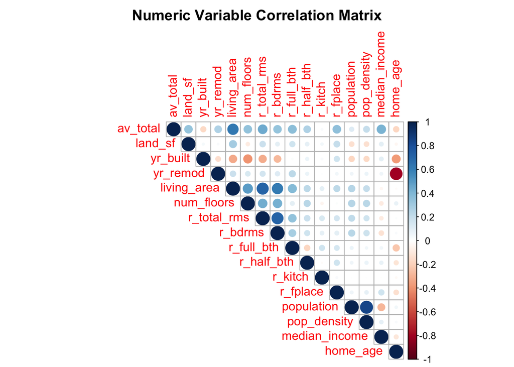

```r
  corrplot(cor_numeric, type = "upper", title = "Numeric Variable Correlation Matrix", mar=c(0,0,2,0))
```

```r
cor_numeric
```

```
##                  av_total     land_sf    yr_built     yr_remod living_area
## av_total       1.00000000  0.33941436 -0.16647138  0.268464455  0.62190524
## land_sf        0.33941436  1.00000000  0.03265587  0.021646834  0.29712489
## yr_built      -0.16647138  0.03265587  1.00000000 -0.145479860 -0.32717057
## yr_remod       0.26846446  0.02164683 -0.14547986  1.000000000  0.18252696
## living_area    0.62190524  0.29712489 -0.32717057  0.182526964  1.00000000
## num_floors     0.34093167 -0.08053148 -0.39606301  0.134159695  0.49452755
## r_total_rms    0.44611810  0.18598115 -0.31432661  0.159435236  0.71873758
## r_bdrms        0.33758330  0.09361292 -0.27096284  0.118899440  0.61809346
## r_full_bth     0.36734870  0.16979697  0.01745600  0.228386200  0.38638223
## r_half_bth     0.26651371  0.08728389  0.06714718  0.065970396  0.22461980
## r_kitch        0.02608308  0.04153958  0.02780826  0.008372181  0.09411469
## r_fplace       0.35095092  0.20490634  0.16742545  0.048461265  0.22108652
## population     0.11525678 -0.13548962 -0.17598785  0.051031258  0.24433856
## pop_density    0.20937688 -0.13426877 -0.16555935  0.061820217  0.20383945
## median_income  0.41565454  0.09515240  0.09427654  0.055609050 -0.03852634
## home_age      -0.17866519 -0.03411728 -0.37149077 -0.791467708 -0.01129629
##                num_floors r_total_rms     r_bdrms  r_full_bth  r_half_bth
## av_total       0.34093167  0.44611810  0.33758330  0.36734870  0.26651371
## land_sf       -0.08053148  0.18598115  0.09361292  0.16979697  0.08728389
## yr_built      -0.39606301 -0.31432661 -0.27096284  0.01745600  0.06714718
## yr_remod       0.13415969  0.15943524  0.11889944  0.22838620  0.06597040
## living_area    0.49452755  0.71873758  0.61809346  0.38638223  0.22461980
## num_floors     1.00000000  0.43159113  0.42060527  0.09809730  0.23023434
## r_total_rms    0.43159113  1.00000000  0.71233926  0.34080538  0.18907661
## r_bdrms        0.42060527  0.71233926  1.00000000  0.28369960  0.16060088
## r_full_bth     0.09809730  0.34080538  0.28369960  1.00000000 -0.17871453
## r_half_bth     0.23023434  0.18907661  0.16060088 -0.17871453  1.00000000
## r_kitch       -0.04234946  0.13810286  0.08915678  0.16141959 -0.01313882
## r_fplace       0.01135135  0.15528593  0.09883324  0.14462403  0.16577667
## population     0.24733148  0.21119007  0.23076398  0.06046422  0.05034922
## pop_density    0.23501276  0.16374938  0.17787095  0.04059175  0.06988254
## median_income -0.08445069 -0.08064828 -0.12972592  0.04849421  0.07374922
## home_age       0.07130847  0.01108513  0.02074320 -0.23822865 -0.11159851
##                    r_kitch    r_fplace   population  pop_density median_income
## av_total       0.026083081  0.35095092  0.115256778  0.209376877   0.415654535
## land_sf        0.041539581  0.20490634 -0.135489621 -0.134268771   0.095152396
## yr_built       0.027808264  0.16742545 -0.175987854 -0.165559354   0.094276536
## yr_remod       0.008372181  0.04846126  0.051031258  0.061820217   0.055609050
## living_area    0.094114685  0.22108652  0.244338563  0.203839454  -0.038526343
```

[output cut: 13 more lines]

```
## land_sf       -0.03411728
## yr_built      -0.37149077
## yr_remod      -0.79146771
## living_area   -0.01129629
## num_floors     0.07130847
## r_total_rms    0.01108513
## r_bdrms        0.02074320
## r_full_bth    -0.23822865
## r_half_bth    -0.11159851
## r_kitch       -0.02101072
## r_fplace      -0.13576529
## population     0.04398217
## pop_density    0.02296302
## median_income -0.10481818
## home_age       1.00000000
```

```r
  #EXCLUDE
  exclude_num <- c ("r_kitch","population", "pop_density", "r_half_bth")

  exclude_num_set <- combined_set[,!names(combined_set) %in% exclude_num]
  exclude_num_set
```

```
## # A tibble: 9,133 × 29
##    pid        zipcode own_occ av_total land_sf yr_built yr_remod living_area
##    <fct>      <chr>   <chr>      <dbl>   <dbl>    <dbl>    <dbl>       <dbl>
##  1 1812296230 02136   Y         321200   10288     1992        0        1681
##  2 2006736000 02132   Y         894400   10148     1900     2016        3024
##  3 2009442000 02132   Y         387700    8512     1920        0        1160
##  4 1704953000 02124   Y         450500    3187     1900     2001        1868
##  5 1812269079 02136   Y         325100   10088     1971     1975        1534
##  6 2011986000 02132   Y         408800    3500     1960     1987        1632
##  7 1902260006 02130   Y         794300    6007     1962     2001        2146
##  8 1807363000 02136   Y         342100    5500     1949     2002        1357
##  9 1601441000 02124   Y         444700    3026     1900        0        2346
## 10 2004674000 02131   Y         518500    4950     1900     2012        2032
## # … with 9,123 more rows, and 21 more variables: num_floors <dbl>,
## #   structure_class <chr>, r_bldg_styl <chr>, r_roof_typ <chr>,
## #   r_ext_fin <chr>, r_total_rms <dbl>, r_bdrms <dbl>, r_full_bth <dbl>,
## #   r_bth_style <chr>, r_kitch_style <chr>, r_heat_typ <chr>, r_ac <chr>,
## #   r_fplace <dbl>, r_ext_cnd <chr>, r_ovrall_cnd <chr>, r_int_cnd <chr>,
## #   r_int_fin <chr>, r_view <chr>, median_income <dbl>, city_state <fct>,
## #   home_age <dbl>
```

```r
  data_exclude_all_set <- exclude_cat_set [,!names(exclude_cat_set) %in% exclude_num]
  data_exclude_all_set
```

```
## # A tibble: 9,133 × 24
##    pid        zipcode av_total land_sf yr_built yr_remod living_area num_floors
##    <fct>      <chr>      <dbl>   <dbl>    <dbl>    <dbl>       <dbl>      <dbl>
##  1 1812296230 02136     321200   10288     1992        0        1681        1
##  2 2006736000 02132     894400   10148     1900     2016        3024        2.5
##  3 2009442000 02132     387700    8512     1920        0        1160        2
##  4 1704953000 02124     450500    3187     1900     2001        1868        2
##  5 1812269079 02136     325100   10088     1971     1975        1534        1
##  6 2011986000 02132     408800    3500     1960     1987        1632        2
##  7 1902260006 02130     794300    6007     1962     2001        2146        2
##  8 1807363000 02136     342100    5500     1949     2002        1357        1.5
##  9 1601441000 02124     444700    3026     1900        0        2346        2.5
## 10 2004674000 02131     518500    4950     1900     2012        2032        2
## # … with 9,123 more rows, and 16 more variables: r_bldg_styl <chr>,
## #   r_roof_typ <chr>, r_ext_fin <chr>, r_total_rms <dbl>, r_bdrms <dbl>,
## #   r_full_bth <dbl>, r_bth_style <chr>, r_kitch_style <chr>, r_heat_typ <chr>,
## #   r_ac <chr>, r_fplace <dbl>, r_ovrall_cnd <chr>, r_int_fin <chr>,
## #   median_income <dbl>, city_state <fct>, home_age <dbl>
```

## Correlations

1. create a correlation matrix of key numeric varaibles like: av_total, land_sf, living_area, and age.

hint: you need to deal with missing values

```r
#CORRELATION MATRIX
combined_correlation_matrix <- data_exclude_all_set %>%
  select_if(is.numeric) %>%
  drop_na() %>%
  cor()
combined_correlation_matrix
```

```
##                 av_total     land_sf    yr_built    yr_remod living_area
## av_total       1.0000000  0.33941436 -0.16647138  0.26846446  0.62190524
## land_sf        0.3394144  1.00000000  0.03265587  0.02164683  0.29712489
## yr_built      -0.1664714  0.03265587  1.00000000 -0.14547986 -0.32717057
## yr_remod       0.2684645  0.02164683 -0.14547986  1.00000000  0.18252696
## living_area    0.6219052  0.29712489 -0.32717057  0.18252696  1.00000000
## num_floors     0.3409317 -0.08053148 -0.39606301  0.13415969  0.49452755
## r_total_rms    0.4461181  0.18598115 -0.31432661  0.15943524  0.71873758
## r_bdrms        0.3375833  0.09361292 -0.27096284  0.11889944  0.61809346
## r_full_bth     0.3673487  0.16979697  0.01745600  0.22838620  0.38638223
## r_fplace       0.3509509  0.20490634  0.16742545  0.04846126  0.22108652
## median_income  0.4156545  0.09515240  0.09427654  0.05560905 -0.03852634
## home_age      -0.1786652 -0.03411728 -0.37149077 -0.79146771 -0.01129629
##                num_floors r_total_rms     r_bdrms  r_full_bth    r_fplace
## av_total       0.34093167  0.44611810  0.33758330  0.36734870  0.35095092
## land_sf       -0.08053148  0.18598115  0.09361292  0.16979697  0.20490634
## yr_built      -0.39606301 -0.31432661 -0.27096284  0.01745600  0.16742545
## yr_remod       0.13415969  0.15943524  0.11889944  0.22838620  0.04846126
## living_area    0.49452755  0.71873758  0.61809346  0.38638223  0.22108652
## num_floors     1.00000000  0.43159113  0.42060527  0.09809730  0.01135135
## r_total_rms    0.43159113  1.00000000  0.71233926  0.34080538  0.15528593
## r_bdrms        0.42060527  0.71233926  1.00000000  0.28369960  0.09883324
## r_full_bth     0.09809730  0.34080538  0.28369960  1.00000000  0.14462403
## r_fplace       0.01135135  0.15528593  0.09883324  0.14462403  1.00000000
## median_income -0.08445069 -0.08064828 -0.12972592  0.04849421  0.16902660
## home_age       0.07130847  0.01108513  0.02074320 -0.23822865 -0.13576529
##               median_income    home_age
## av_total         0.41565454 -0.17866519
## land_sf          0.09515240 -0.03411728
## yr_built         0.09427654 -0.37149077
## yr_remod         0.05560905 -0.79146771
## living_area     -0.03852634 -0.01129629
## num_floors      -0.08445069  0.07130847
## r_total_rms     -0.08064828  0.01108513
## r_bdrms         -0.12972592  0.02074320
## r_full_bth       0.04849421 -0.23822865
## r_fplace         0.16902660 -0.13576529
## median_income    1.00000000 -0.10481818
## home_age        -0.10481818  1.00000000
```

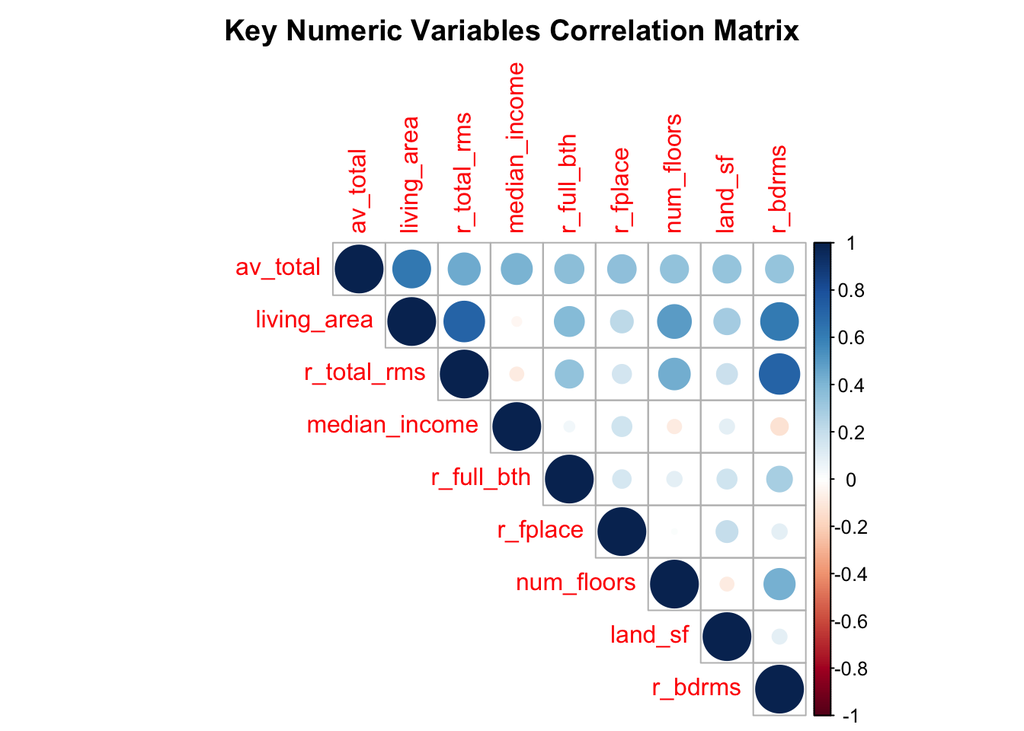

```r
#CORRELATION PLOT
key_correlation_matrix <- data_exclude_all_set %>%
  select(av_total, living_area, r_total_rms, median_income, r_full_bth, r_fplace, num_floors, land_sf, r_bdrms) %>%
  drop_na() %>%
  cor()
  corrplot(key_correlation_matrix, type="upper", title = "Key Numeric Variables Correlation Matrix", mar=c(0,0,2,0))
```

```r
key_correlation_matrix
```

```
##                av_total living_area r_total_rms median_income r_full_bth
## av_total      1.0000000  0.62190524  0.44611810    0.41565454 0.36734870
## living_area   0.6219052  1.00000000  0.71873758   -0.03852634 0.38638223
## r_total_rms   0.4461181  0.71873758  1.00000000   -0.08064828 0.34080538
## median_income 0.4156545 -0.03852634 -0.08064828    1.00000000 0.04849421
## r_full_bth    0.3673487  0.38638223  0.34080538    0.04849421 1.00000000
## r_fplace      0.3509509  0.22108652  0.15528593    0.16902660 0.14462403
## num_floors    0.3409317  0.49452755  0.43159113   -0.08445069 0.09809730
## land_sf       0.3394144  0.29712489  0.18598115    0.09515240 0.16979697
## r_bdrms       0.3375833  0.61809346  0.71233926   -0.12972592 0.28369960
##                 r_fplace  num_floors     land_sf     r_bdrms
## av_total      0.35095092  0.34093167  0.33941436  0.33758330
## living_area   0.22108652  0.49452755  0.29712489  0.61809346
## r_total_rms   0.15528593  0.43159113  0.18598115  0.71233926
## median_income 0.16902660 -0.08445069  0.09515240 -0.12972592
## r_full_bth    0.14462403  0.09809730  0.16979697  0.28369960
## r_fplace      1.00000000  0.01135135  0.20490634  0.09883324
## num_floors    0.01135135  1.00000000 -0.08053148  0.42060527
## land_sf       0.20490634 -0.08053148  1.00000000  0.09361292
## r_bdrms       0.09883324  0.42060527  0.09361292  1.00000000
```

## Explore Categorical Predictors

find 4 categorical variables are likely to be useful in predicting home prices?

- use a chart comparing the category with av_total,
- a useful variable will have differences in the mean of av_total
- for example a boxplot of zipcode vs av_total is telling.

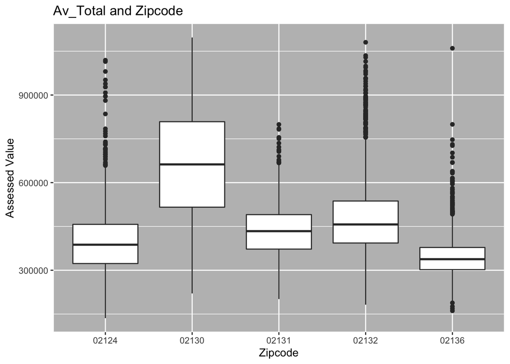

```r
#Zip vs AV
zip_vs_av <-data_exclude_all_set %>%
  ggplot(aes(y = av_total, x = zipcode)) +
  geom_boxplot()+
  theme(panel.background = element_rect(fill = "gray",
                                colour = "white",
                                size = 0.5, linetype = "solid")) +
 labs(title = "Av_Total and Zipcode", x = "Zipcode", y= "Assessed Value")
zip_vs_av
```

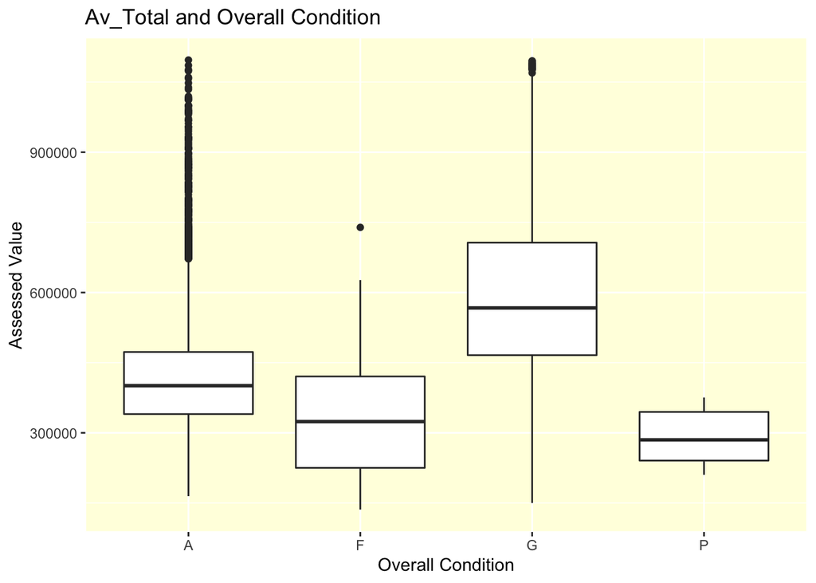

```r
#Condition vs AV
over_cnd_VS_av <-data_exclude_all_set %>%
  ggplot(aes(y = av_total, x = r_ovrall_cnd)) +
  geom_boxplot()+
  theme(panel.background = element_rect(fill = "lightyellow",
                                colour = "white",
                                size = 0.5, linetype = "solid")) +
 labs(title = "Av_Total and Overall Condition", x = "Overall Condition", y= "Assessed Value")
over_cnd_VS_av
```

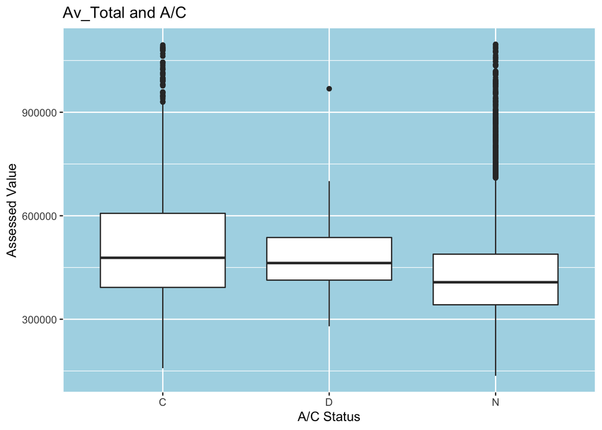

```r
#AC vs AV
ac_vs_av <-data_exclude_all_set %>%
  ggplot(aes(y = av_total, x = r_ac)) +
  geom_boxplot()+
  theme(panel.background = element_rect(fill = "lightblue",
                                colour = "white",
                                size = 0.5, linetype = "solid")) +
 labs(title = "Av_Total and A/C", x = "A/C Status", y= "Assessed Value")
ac_vs_av
```

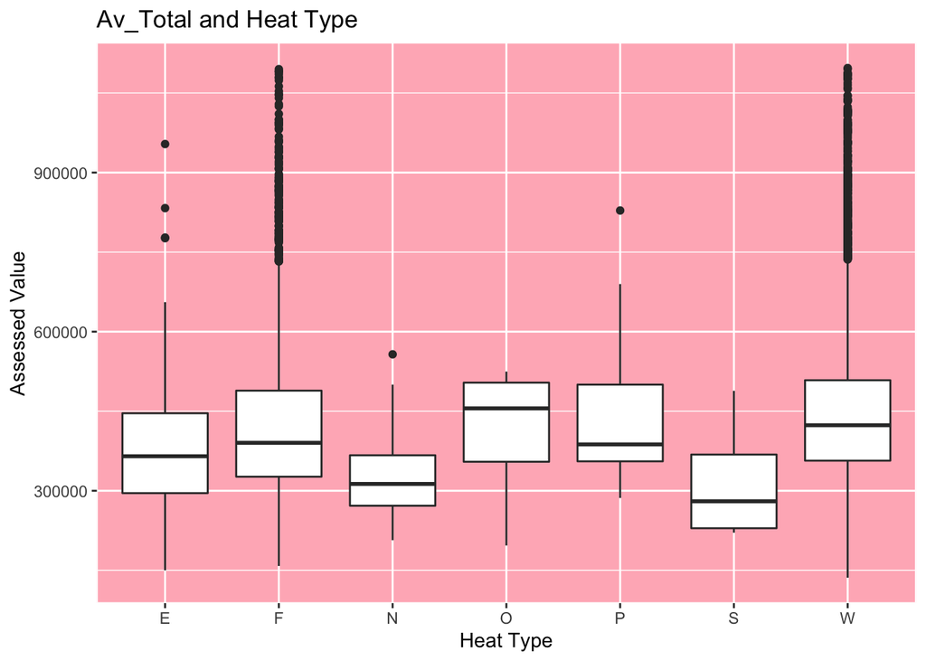

```r
#Heat_type vs AV
heat_vs_av <-data_exclude_all_set %>%
  ggplot(aes(y = av_total, x = r_heat_typ)) +
  geom_boxplot()+
  theme(panel.background = element_rect(fill = "lightpink",
                                colour = "white",
                                size = 0.5, linetype = "solid")) +
 labs(title = "Av_Total and Heat Type", x = "Heat Type", y= "Assessed Value")
heat_vs_av
```

```r
## Categorical Variable: Zipcode, R_OVERALL_CND, R_FPLACE, R_HEAT_TYPE, R_ac, City_State
categorical_predictors <- c("zipcode", "r_ovrall_cnd", "r_ac", "r_heat_typ")

categorical_predictors_factor   <-as.factor(categorical_predictors)
```

### Prepare your data

1. select the following columns
- pid
- av_total
- age
- land_sf
- living_area
- num_floors
- population
- median_income
- city_state

PLUS your 4 character columns you think will be useful

2. Convert character columns to factors
- hint: mutate_at(c(“var1”, …), as.factor)

```r
#Change them all from numeric to factor
prepped_data <- combined_set %>%
  select(pid, av_total, home_age, land_sf, living_area, num_floors, population, median_income, city_state, categorical_predictors_factor) %>%
  na.omit(prepped_data)
 prepped_data
```

```
## # A tibble: 9,133 × 13
##    pid        av_total home_age land_sf living_area num_floors population
##    <fct>         <dbl>    <dbl>   <dbl>       <dbl>      <dbl>      <dbl>
##  1 1812296230   321200       28   10288        1681        1        28488
##  2 2006736000   894400        4   10148        3024        2.5      36314
##  3 2009442000   387700      100    8512        1160        2        36314
##  4 1704953000   450500       19    3187        1868        2        47783
##  5 1812269079   325100       45   10088        1534        1        28488
##  6 2011986000   408800       33    3500        1632        2        36314
##  7 1902260006   794300       19    6007        2146        2        35401
##  8 1807363000   342100       18    5500        1357        1.5      28488
##  9 1601441000   444700      120    3026        2346        2.5      47783
## 10 2004674000   518500        8    4950        2032        2        29826
## # … with 9,123 more rows, and 6 more variables: median_income <dbl>,
## #   city_state <fct>, zipcode <chr>, r_ovrall_cnd <chr>, r_ac <chr>,
## #   r_heat_typ <chr>
```

## 1. Partition your data 70/30 (train / test split)

1. split your data set into 70% training and 30% test
2. print out the % of each data set

```r
#Partition 70/30
sample <- sample.int(n = 9133, size = floor(9133*.7))
train <- prepped_data[sample,]
test <- prepped_data[-sample,]

train
```

```
## # A tibble: 6,393 × 13
##    pid        av_total home_age land_sf living_area num_floors population
##    <fct>         <dbl>    <dbl>   <dbl>       <dbl>      <dbl>      <dbl>
##  1 1605213000   364200      100    3917        1378          2      47783
##  2 1902214001   842800       96    6723        2172          2      35401
##  3 1808549000   327400       72    4968        1252          1      28488
##  4 2012060011   339100       52    6073        1343          1      36314
##  5 1812890001   311200       65    4276         968          1      28488
##  6 1812102000   297500       59    4770         988          1      28488
##  7 2008106000   413200       14    3609        1392          2      36314
##  8 1603067000   454900       26    6570        2479          2      47783
##  9 1810885000   380500       90    6000        1440          2      28488
## 10 2002980000   289300       75    4108        1254          1      36314
## # … with 6,383 more rows, and 6 more variables: median_income <dbl>,
## #   city_state <fct>, zipcode <chr>, r_ovrall_cnd <chr>, r_ac <chr>,
## #   r_heat_typ <chr>
```

```r
test
```

```
## # A tibble: 2,740 × 13
##    pid        av_total home_age land_sf living_area num_floors population
##    <fct>         <dbl>    <dbl>   <dbl>       <dbl>      <dbl>      <dbl>
##  1 2006736000   894400        4   10148        3024        2.5      36314
##  2 2009442000   387700      100    8512        1160        2        36314
##  3 1902260006   794300       19    6007        2146        2        35401
##  4 1807363000   342100       18    5500        1357        1.5      28488
##  5 1703060000   329200       95    4449        1224        2        47783
##  6 2006908000   313800       31    4001         988        1        36314
##  7 1807040000   395400       53   10335        1274        2        28488
##  8 2004380000   590700       12    8652        2072        2        36314
##  9 1811716000   306700       95    4875        1134        2        28488
## 10 1700277010   240600       36    2712         918        2        47783
## # … with 2,730 more rows, and 6 more variables: median_income <dbl>,
## #   city_state <fct>, zipcode <chr>, r_ovrall_cnd <chr>, r_ac <chr>,
## #   r_heat_typ <chr>
```

## 2. Train model 1

for example: model_1 <- lm(av_total ~ living_area + age + num_floors, data=train)

```r
model_1 <- lm(av_total ~  land_sf + living_area + city_state + r_ovrall_cnd,  data = train)
summary(model_1)
```

```
##
## Call:
## lm(formula = av_total ~ land_sf + living_area + city_state +
##     r_ovrall_cnd, data = train)
##
## Residuals:
##     Min      1Q  Median      3Q     Max
## -562212  -37003    3783   40843  346406
##
## Coefficients:
##                                     Estimate   Std. Error t value
## (Intercept)                      195768.2261    3333.9053  58.720
## land_sf                               8.7050       0.3444  25.276
## living_area                         131.8060       1.8208  72.390
## city_stateDorchester Center, MA  -99834.5403    2846.9508 -35.067
## city_stateHyde Park, MA         -106289.4513    2363.0796 -44.979
## city_stateJamaica Plain, MA      151933.0611    3332.9605  45.585
## city_stateRoslindale, MA         -21784.5981    2542.4795  -8.568
## r_ovrall_cndF                   -115043.1144   10266.5062 -11.206
## r_ovrall_cndG                     90218.0301    2571.1334  35.089
## r_ovrall_cndP                   -207121.7607   31355.5112  -6.606
##                                             Pr(>|t|)
## (Intercept)                     < 0.0000000000000002 ***
## land_sf                         < 0.0000000000000002 ***
## living_area                     < 0.0000000000000002 ***
## city_stateDorchester Center, MA < 0.0000000000000002 ***
## city_stateHyde Park, MA         < 0.0000000000000002 ***
## city_stateJamaica Plain, MA     < 0.0000000000000002 ***
## city_stateRoslindale, MA        < 0.0000000000000002 ***
## r_ovrall_cndF                   < 0.0000000000000002 ***
## r_ovrall_cndG                   < 0.0000000000000002 ***
## r_ovrall_cndP                        0.0000000000428 ***
## ---
## Signif. codes:  0 '***' 0.001 '**' 0.01 '*' 0.05 '.' 0.1 ' ' 1
##
## Residual standard error: 70010 on 6383 degrees of freedom
## Multiple R-squared:  0.7672, Adjusted R-squared:  0.7669
## F-statistic:  2337 on 9 and 6383 DF,  p-value: < 0.00000000000000022
```

```r
glance(model_1)
```

```
## # A tibble: 1 × 12
##   r.squared adj.r.squared  sigma statistic p.value    df  logLik     AIC     BIC
##       <dbl>         <dbl>  <dbl>     <dbl>   <dbl> <dbl>   <dbl>   <dbl>   <dbl>
## 1     0.767         0.767 70012.     2337.       0     9 -80389. 160801. 160875.
## # … with 3 more variables: deviance <dbl>, df.residual <int>, nobs <int>
```

## 3. Train model 2

for example: model_2 <- lm(av_total ~ living_area + age + num_floors + , data=train)

```r
prepped_data
```

```
## # A tibble: 9,133 × 13
##    pid        av_total home_age land_sf living_area num_floors population
##    <fct>         <dbl>    <dbl>   <dbl>       <dbl>      <dbl>      <dbl>
##  1 1812296230   321200       28   10288        1681        1        28488
##  2 2006736000   894400        4   10148        3024        2.5      36314
##  3 2009442000   387700      100    8512        1160        2        36314
##  4 1704953000   450500       19    3187        1868        2        47783
##  5 1812269079   325100       45   10088        1534        1        28488
##  6 2011986000   408800       33    3500        1632        2        36314
##  7 1902260006   794300       19    6007        2146        2        35401
##  8 1807363000   342100       18    5500        1357        1.5      28488
##  9 1601441000   444700      120    3026        2346        2.5      47783
## 10 2004674000   518500        8    4950        2032        2        29826
## # … with 9,123 more rows, and 6 more variables: median_income <dbl>,
## #   city_state <fct>, zipcode <chr>, r_ovrall_cnd <chr>, r_ac <chr>,
## #   r_heat_typ <chr>
```

```r
model_2 <- lm(av_total ~  land_sf + living_area + city_state + r_ovrall_cnd + population + median_income + zipcode + r_ac + num_floors  + r_heat_typ + home_age  , data = train)
summary(model_2)
```

```
##
## Call:
## lm(formula = av_total ~ land_sf + living_area + city_state +
##     r_ovrall_cnd + population + median_income + zipcode + r_ac +
##     num_floors + r_heat_typ + home_age, data = train)
##
## Residuals:
##     Min      1Q  Median      3Q     Max
## -538289  -36089    2934   38854  326297
##
## Coefficients: (6 not defined because of singularities)
##                                    Estimate  Std. Error t value
## (Intercept)                      154240.180    8850.051  17.428
## land_sf                               9.643       0.344  28.032
## living_area                         117.166       2.049  57.194
## city_stateDorchester Center, MA  -97548.479    2826.908 -34.507
## city_stateHyde Park, MA         -101792.269    2331.773 -43.654
## city_stateJamaica Plain, MA      152490.644    3249.405  46.929
## city_stateRoslindale, MA         -20638.956    2497.639  -8.263
## r_ovrall_cndF                   -108025.291   10004.912 -10.797
## r_ovrall_cndG                     78263.488    2636.631  29.683
## r_ovrall_cndP                   -199331.778   30442.406  -6.548
## population                               NA          NA      NA
## median_income                            NA          NA      NA
## zipcode02130                             NA          NA      NA
## zipcode02131                             NA          NA      NA
## zipcode02132                             NA          NA      NA
## zipcode02136                             NA          NA      NA
## r_acD                              4836.779   11735.359   0.412
## r_acN                            -21258.217    2623.494  -8.103
## num_floors                        31727.734    2328.682  13.625
## r_heat_typF                       32446.510    7850.007   4.133
## r_heat_typN                       -8541.265   22836.008  -0.374
## r_heat_typO                       24959.369   40007.194   0.624
## r_heat_typP                       -2612.676   18731.641  -0.139
## r_heat_typS                      -57748.348   48670.797  -1.187
## r_heat_typW                       41156.754    7701.491   5.344
## home_age                           -234.580      23.310 -10.064
##                                             Pr(>|t|)
## (Intercept)                     < 0.0000000000000002 ***
```

[output cut: 16 more lines]

```
## r_acN                           0.000000000000000637 ***
## num_floors                      < 0.0000000000000002 ***
## r_heat_typF                     0.000036216149994674 ***
## r_heat_typN                                    0.708
## r_heat_typO                                    0.533
## r_heat_typP                                    0.889
## r_heat_typS                                    0.235
## r_heat_typW                     0.000000094072451011 ***
## home_age                        < 0.0000000000000002 ***
## ---
## Signif. codes:  0 '***' 0.001 '**' 0.01 '*' 0.05 '.' 0.1 ' ' 1
##
## Residual standard error: 67960 on 6373 degrees of freedom
## Multiple R-squared:  0.781,  Adjusted R-squared:  0.7803
## F-statistic:  1196 on 19 and 6373 DF,  p-value: < 0.00000000000000022
```

```r
glance(model_2)
```

```
## # A tibble: 1 × 12
##   r.squared adj.r.squared  sigma statistic p.value    df  logLik     AIC     BIC
##       <dbl>         <dbl>  <dbl>     <dbl>   <dbl> <dbl>   <dbl>   <dbl>   <dbl>
## 1     0.781         0.780 67960.     1196.       0    19 -80194. 160430. 160572.
## # … with 3 more variables: deviance <dbl>, df.residual <int>, nobs <int>
```

## 4. MAKE PREDICTIONS

make predictions on training and test for each model

for example, do this 4 times:

train$model_1_pred <- predict(model1,train)

or use https://modelr.tidyverse.org/reference/add_predictions.html

add_predictions to do the same thing

```r
# -- apply the models

#Train set predictions
train$model_1_pred <- predict(model_1, train)
train$model_2_pred  <- predict(model_2, train)

#Calculate Difference
train %>%
mutate(model_1_difference = model_1_pred - av_total)%>%
 mutate(model_2_difference = model_2_pred - av_total)
```

```
## # A tibble: 6,393 × 17
##    pid        av_total home_age land_sf living_area num_floors population
##    <fct>         <dbl>    <dbl>   <dbl>       <dbl>      <dbl>      <dbl>
##  1 1605213000   364200      100    3917        1378          2      47783
##  2 1902214001   842800       96    6723        2172          2      35401
##  3 1808549000   327400       72    4968        1252          1      28488
##  4 2012060011   339100       52    6073        1343          1      36314
##  5 1812890001   311200       65    4276         968          1      28488
##  6 1812102000   297500       59    4770         988          1      28488
##  7 2008106000   413200       14    3609        1392          2      36314
##  8 1603067000   454900       26    6570        2479          2      47783
##  9 1810885000   380500       90    6000        1440          2      28488
## 10 2002980000   289300       75    4108        1254          1      36314
## # … with 6,383 more rows, and 10 more variables: median_income <dbl>,
## #   city_state <fct>, zipcode <chr>, r_ovrall_cnd <chr>, r_ac <chr>,
## #   r_heat_typ <chr>, model_1_pred <dbl>, model_2_pred <dbl>,
## #   model_1_difference <dbl>, model_2_difference <dbl>
```

```r
#Test set predictions
test$ model_1_predict <- predict(model_1, test)
test$ model_2_predict <- predict(model_2, test)

#Calculate Difference
test <- test%>% mutate(model_1_difference = model_1_predict - av_total) %>%
 mutate(model_2_difference = model_2_predict - av_total)
test
```

```
## # A tibble: 2,740 × 17
##    pid        av_total home_age land_sf living_area num_floors population
##    <fct>         <dbl>    <dbl>   <dbl>       <dbl>      <dbl>      <dbl>
##  1 2006736000   894400        4   10148        3024        2.5      36314
##  2 2009442000   387700      100    8512        1160        2        36314
##  3 1902260006   794300       19    6007        2146        2        35401
##  4 1807363000   342100       18    5500        1357        1.5      28488
##  5 1703060000   329200       95    4449        1224        2        47783
##  6 2006908000   313800       31    4001         988        1        36314
##  7 1807040000   395400       53   10335        1274        2        28488
##  8 2004380000   590700       12    8652        2072        2        36314
##  9 1811716000   306700       95    4875        1134        2        28488
## 10 1700277010   240600       36    2712         918        2        47783
## # … with 2,730 more rows, and 10 more variables: median_income <dbl>,
## #   city_state <fct>, zipcode <chr>, r_ovrall_cnd <chr>, r_ac <chr>,
## #   r_heat_typ <chr>, model_1_predict <dbl>, model_2_predict <dbl>,
## #   model_1_difference <dbl>, model_2_difference <dbl>
```

## 5. Calculate Evaluatation Metrics

use modelr package or do it by hand but you’ll want to calculate for both training and test datasets for each of your two models, you need to be able to explain what these metrics mean. is a large RMSE good or bad? is a large RSQUARE good or bad, how do you interpret RSQUARE? mse() rmse() mae() rsquare()

https://modelr.tidyverse.org/reference/index.html

```r
#Mod1_train
print("model_1_train: Metrics")
```

```
## [1] "model_1_train: Metrics"
```

```r
sprintf("The MSE is %.02f", mse(model_1, train))
```

```
## [1] "The MSE is 4894000954.79"
```

```r
sprintf("The RMSE is %.02f", rmse(model_1, train))
```

```
## [1] "The RMSE is 69957.14"
```

```r
sprintf("The MAE is %.02f", mae(model_1, train))
```

```
## [1] "The MAE is 52001.04"
```

```r
sprintf("The RSQUARE is %.02f", rsquare(model_1, train))
```

```
## [1] "The RSQUARE is 0.77"
```

```r
print("---------------")
```

```
## [1] "---------------"
```

```r
#Mod2_train
print("model_2_train: Metrics")
```

```
## [1] "model_2_train: Metrics"
```

```r
sprintf("The MSE is %.02f", mse(model_2, train))
```

```
## [1] "The MSE is 4604046403.19"
```

```r
sprintf("The RMSE is %.02f", rmse(model_2, train))
```

```
## [1] "The RMSE is 67853.12"
```

```r
sprintf("The MAE is %.02f", mae(model_2, train))
```

```
## [1] "The MAE is 50079.51"
```

```r
sprintf("The RSQUARE is %.02f", rsquare(model_2, train))
```

```
## [1] "The RSQUARE is 0.78"
```

```r
print("---------------")
```

```
## [1] "---------------"
```

```r
#mod1_test
print("Model_1 Test: Metrics")
```

```
## [1] "Model_1 Test: Metrics"
```

```r
sprintf("The MSE is %.02f", mse(model_1, test))
```

```
## [1] "The MSE is 4964945430.78"
```

```r
sprintf("The RMSE is %.02f", rmse(model_1, test))
```

```
## [1] "The RMSE is 70462.37"
```

```r
sprintf("The MAE is %.02f", mae(model_1, test))
```

```
## [1] "The MAE is 51483.92"
```

```r
sprintf("The RSQUARE is %.02f", rsquare(model_1, test))
```

```
## [1] "The RSQUARE is 0.76"
```

```r
#mod2_test
print("---------------")
```

```
## [1] "---------------"
```

```r
print("Model_2 Test: Metrics")
```

```
## [1] "Model_2 Test: Metrics"
```

```r
sprintf("The MSE is %.02f", mse(model_2, test))
```

```
## [1] "The MSE is 4755905412.56"
```

```r
sprintf("The RMSE is %.02f", rmse(model_2, test))
```

```
## [1] "The RMSE is 68963.07"
```

```r
sprintf("The MAE is %.02f", mae(model_2, test))
```

```
## [1] "The MAE is 50261.29"
```

```r
sprintf("The RSQUARE is %.02f", rsquare(model_2, test))
```

```
## [1] "The RSQUARE is 0.77"
```

## 6. Which PREDICTIONS did great, over and underestimated av_total?

using only your TEST partition what are the top 10 houses 1. that your best linear regression did the best predicting residual closest to zero 2. that your best linear regression overestimated av_total  
3. that your best linear regression underestimated av_total

```r
#Trim to just important variables for analysis, not all of them knit
test_trimmed <- test %>%
  select(pid,city_state,av_total,model_2_predict, model_2_difference)

Ten_best <- test_trimmed %>%
  mutate(model_2_difference = abs(model_2_difference)) %>%
  slice_min(order_by = model_2_difference, n =10)
Ten_best
```

```
## # A tibble: 10 × 5
##    pid        city_state            av_total model_2_predict model_2_difference
##    <fct>      <fct>                    <dbl>           <dbl>              <dbl>
##  1 1806202000 Roslindale, MA          296500         296464.               36.5
##  2 1703608000 Dorchester Center, MA   390200         390145.               55.0
##  3 1703085000 Dorchester Center, MA   331300         331243.               57.2
##  4 1811307000 Hyde Park, MA           340100         340161.               61.1
##  5 1804080000 Hyde Park, MA           283200         283109.               91.1
##  6 1810784000 Hyde Park, MA           339800         339632.              168.
##  7 1601686000 Dorchester Center, MA   377200         377441.              241.
##  8 2001181000 Roslindale, MA          411400         411119.              281.
##  9 2009282001 Cambridge, MA           374600         374930.              330.
## 10 1703058000 Dorchester Center, MA   322400         322000.              400.
```

```r
OverEstimated_Ten <- test_trimmed %>%
  slice_max(order_by = model_2_difference, n =10)
OverEstimated_Ten
```

```
## # A tibble: 10 × 5
##    pid        city_state            av_total model_2_predict model_2_difference
##    <fct>      <fct>                    <dbl>           <dbl>              <dbl>
##  1 1700653000 Dorchester Center, MA   164700         764758.            600058.
##  2 1402790000 Dorchester Center, MA   296400         713639.            417239.
##  3 1102412000 Jamaica Plain, MA       609800         851672.            241872.
##  4 1602878000 Dorchester Center, MA   384700         625631.            240931.
##  5 1102196000 Jamaica Plain, MA       299500         514357.            214857.
##  6 1700060000 Dorchester Center, MA   295400         509533.            214133.
##  7 1904486000 Jamaica Plain, MA       497000         707679.            210679.
##  8 1103007000 Jamaica Plain, MA       763100         973317.            210217.
##  9 1102437000 Jamaica Plain, MA       739300         948136.            208836.
## 10 1402240000 Dorchester Center, MA   320200         526921.            206721.
```

```r
UnderEstimated <- test_trimmed %>%
  slice_min(order_by = model_2_difference, n=10)
UnderEstimated
```

```
## # A tibble: 10 × 5
##    pid        city_state        av_total model_2_predict model_2_difference
##    <fct>      <fct>                <dbl>           <dbl>              <dbl>
##  1 1902770000 Jamaica Plain, MA  1062620         720293.           -342327.
##  2 1902490000 Jamaica Plain, MA  1038480         718216.           -320264.
##  3 1901603000 Jamaica Plain, MA  1047900         745417.           -302483.
##  4 1901863000 Jamaica Plain, MA   944600         659848.           -284752.
##  5 1901977001 Jamaica Plain, MA  1045072         760385.           -284687.
##  6 1902064000 Jamaica Plain, MA  1083700         799497.           -284203.
##  7 1902119000 Jamaica Plain, MA  1000300         721642.           -278658.
##  8 1901553000 Jamaica Plain, MA  1078000         799753.           -278247.
##  9 1901539000 Jamaica Plain, MA  1012460         741291.           -271169.
## 10 1902310002 Jamaica Plain, MA  1095000         829852.           -265148.
```

your notebook should knit from begging to end, and should be your own work!!!